# M2 Project

Maheswar Raju Narasaiah

2022-10-13

**ALY 6000 - Introduction to Analytics**  
**Northeastern University**

Maheswar Raju Narasaiah  
Date: 29 October, 2022

Project 2 - Executive Report

# 1 1. Introduction

Simply put, statistics is the branch of applied mathematics concerned with data collection, organization, analysis, interpretation, and presentation. Does this sound familiar? It ought to. All of these steps are critical in the data analytics process. In fact, data analytics is similar to statistics in many ways. When we say “data analytics,” we really mean “the statistical analysis of a given dataset or datasets.” But that’s a mouthful, so we usually shorten it!

Statistics are critical to any field in which data analysts work because they are so fundamental to data analytics. The wide range of statistical techniques available, from science and psychology to marketing and medicine, can be broadly divided into two categories: descriptive statistics and inferential statistics. But what’s the distinction between them?

**1.1. What is descriptive statistics?**

Descriptive statistics are used to describe the properties or characteristics of a dataset. The term “descriptive statistics” can refer to both individual quantitative observations (also known as “summary statistics”) and the overall process of gaining insights from these data (Braun & Murdoch, 2021). Descriptive statistics can be used to describe an entire population or an individual sample. Because descriptive statistics are merely explanatory, they are unconcerned with the distinctions between the two types of data.

**1.2. What is inferential statistics?**

As previously stated, descriptive statistics are concerned with summarizing the key features of a dataset. Meanwhile, inferential statistics are concerned with making broad statements about a larger population based on a representative sample of that population. Because inferential statistics is concerned with making predictions rather than stating facts, its outcomes are typically in the form of a probability.

Inferential statistics, predictably, rely heavily on sample data that is both accurate and representative of the larger population. Obtaining a random sample is required to accomplish this. If you’ve ever read about scientific studies in the news, you’ve probably come across the term. The implication is that random sampling produces better results. Results based on biased or non-random samples, on the other hand, are usually discarded. Random sampling is critical for performing inferential techniques, but it is not always simple!

**1.3. Importance of Proper Data Presentation?**

- Information reports are the edge of any organization. An organization require not be included with budgetary exchanges straightforwardly some time recently information can be collated. Information detailing is primarily for the reason of responsibility, administration, and organization (Peng, 2016).
- The right reporting, analytics and information delivery strategy can have a significant impact on an organization, fundamentally changing the way people perform their jobs and how decisions are made. The benefits of a successful strategy include:  
  - Targeted delivery of data and reporting and analytics capabilities  
  - Increased productivity  
  - Employee satisfaction  
  - Improved analysis and decision-making  
  - Increased organizational communication and collaboration
- Reporting, analysis and delivery of information can have a transformative impact on an organization when implemented correctly. But deciding which features to use can be a daunting task for many businesses. There are many options, and by focusing on each and how to align them with business goals, organizations can improve the success of their overall business intelligence environment.
- Raw data analysis makes research and innovation easier and more efficient. These reports vary according to different topics, but the end point and purpose of data analysis reports is to provide information about the platform you are using.

**1.4. Practical Applications of R in Data Analysis?**

Some of the important applications of R Programming Language in the domain of Data Science are:

**1.4.1. Finance** - R enables financial institutions to perform risk measurements, adjust risk performance and use visualizations such as candlestick charts, density charts, etc. R also provides tools to perform moving averages, autoregression and time series analysis. forms the core of financial applications. R is widely used for credit risk analysis in companies such as ANZ and portfolio management. The financial sector also uses R’s time series statistical processes to model its stock market movements and forecast stock prices. R also provides options for economic data mining through its own packages such as quantmod, pdfetch, TFX, pwt, etc. R lets you easily retrieve information from network assets. With RShiny, you can also present your financial products with lively and interesting visualizations.

**1.4.2. Banking** - Like financial institutions, the banking industry uses R for credit risk modeling and other risk analyses. Banks use a lot of mortgage discount, which allows them to take over the property if the loan defaults. Mortgage Hairton modeling includes sale price distribution, sale price volatility and expected drawdown calculation. For these purposes, R is often used in conjunction with proprietary tools such as SAS (Chambers, 2008). R is also used with Hadoop to facilitate customer quality analysis, customer segmentation and retention.

Bank of America makes use of R for financial reporting. With the help of R, the data scientists at BOA are able to analyze financial losses and make use of R’s visualization tools.

**1.4.3. Healthcare** - Genetics, bioinformatics, drug research, epidemiology are some of the health fields where R is heavily used. With R, these companies can compress data and process information, providing an important background for further analysis and data processing (Sackmann, 1996). For advanced processing, such as drug development, R is most often used in preclinical studies and pharmacovigilance data analysis. It also provides users with exploratory data analysis and real-time visualization tools. R is also popular for its Bioconductor package, which provides various functions for analyzing genomic data. R is also used for statistical modeling in the field of epidemiology, where data scientists analyze and predict the spread of diseases.

**1.4.4. Social Media** - For many Data Science and R beginners, social media is a data playground. Sentiment analysis and other forms of social media data mining are important statistical tools used with R . Social media is also a challenging area for data science because the data shared on social media sites is largely unstructured. R is used for social media analysis, segmentation and targeting of potential customers to sell your products. Additionally, miner opinion is another popular category in social media analytics. R enables companies to model statistical tools that analyze user sentiment, allowing them to improve their experiences.

# 2 2. Analysis

```r
#Library Used in Project
library(magrittr)
library(knitr)
library(plyr)
library(dplyr)
library(readxl)
library(gridExtra)
library(RColorBrewer)
library(lattice)
library(ggplot2)
library(DT)
library(kableExtra)


# Datasets used in Project
SalesData <- read_excel("Data Sets/M2Project_Data-1.xlsx")
```

## 2.1 Task 1 - Present the first 5 and the last 5 records from the dataset

```r
#Creating a new vector for first 5  records
hSalesData <- head(SalesData,5)

#Creating a new vector for last 5  records
tSalesData <- tail(SalesData,5)

#Rbind for head and tail vector
new_SalesData <- rbind(hSalesData,tSalesData)

#Present the table
knitr::kable(new_SalesData,
             caption = "Presenting the Sales table",
             format = "html",
             table.attr="style=width: 40%", align = "lccrr") %>%
 kable_styling(bootstrap_options = c("striped", "hover", "condensed", "responsive")) %>%
  kable_classic(full_width = F, html_font = "Times New Roman")
```

Presenting the Sales table

| Region | Market | Company_Segment | Product_Category | Product_SubCategory | Price | Quantity | Sales | Profits | ShippingCost |
| --- | --- | --- | --- | --- | --- | --- | --- | --- | --- |
| Central US | USCA | Consumer | Technology | Phones | 221.98 | 2 | 443.96 | 62.15 | 40.77 |
| Oceania | Asia Pacific | Corporate | Furniture | Chairs | 3709.40 | 9 | 33384.60 | -288.77 | 923.63 |
| Oceania | Asia Pacific | Consumer | Technology | Phones | 5175.17 | 9 | 46576.53 | 919.97 | 915.49 |
| Western Europe | Europe | Home Office | Technology | Phones | 2892.51 | 5 | 14462.55 | -96.54 | 910.16 |
| Western Africa | Africa | Consumer | Technology | Copiers | 2832.96 | 8 | 22663.68 | 311.52 | 903.04 |
| Eastern Asia | Asia Pacific | Consumer | Furniture | Tables | 2614.69 | 7 | 18302.83 | -821.96 | 203.26 |
| Western US | USCA | Corporate | Office Supplies | Appliances | 69.48 | 1 | 69.48 | 20.84 | 12.04 |
| Oceania | Asia Pacific | Consumer | Technology | Copiers | 636.78 | 2 | 1273.56 | 286.50 | 203.20 |
| South America | LATAM | Corporate | Furniture | Bookcases | 2751.20 | 10 | 27512.00 | 110.00 | 203.13 |
| Southeastern Asia | Asia Pacific | Corporate | Technology | Phones | 1587.00 | 3 | 4761.00 | -76.56 | 203.08 |

### 2.1.1 Observation

- The vector SalesData is created to store the first 5 records from SalesData using code head().
- The vector SalesData is created to store the last 5 records from SalesData using code tail().
- With the help of code rbind(), we merge the SalesData and SalesData in a new dataset new_SalesData.
- The above table encapsulate the sales data for office product supplies like Phones, Copiers, Machines, etc. across various region such as “Africa”,“Asia Pacific”,“Europe”,“LATAM”,“USCA”.
- The table new_SalesData provides us the glimpse of market requirement and demand.

## 2.2 Task 2 - Present a table with all categories of Market and their frequencies

```r
#Initializing a new vector
Market <- SalesData$Market
Prod_Category <- SalesData$Product_Category
Prod_Subcategory <- SalesData$Product_SubCategory

#Initializing a new vector
Market <- SalesData$Market
Prod_Category <- SalesData$Product_Category
Prod_Subcategory <- SalesData$Product_SubCategory
Region <- SalesData$Region

#Calculating Frequencies for Market and categories
table1 <- table(Market,Prod_Subcategory)
table2 <- table(Market)
table3 <- table(Prod_Category)
table4 <- table(Prod_Subcategory)
table5 <- table(Market,Prod_Category)

#Present the table using knitr::kable()

knitr::kable(table2,
             caption = "Market Category : Frequency",
             format = "html",
             table.attr="style=width: 40%", align = "lccrr") %>%
 kable_styling(bootstrap_options = c("striped", "hover", "condensed", "responsive")) %>%
  kable_classic(full_width = F, html_font = "Times New Roman")
```

Market Category : Frequency

| Market | Freq |
| --- | --- |
| Africa | 54 |
| Asia Pacific | 365 |
| Europe | 248 |
| LATAM | 133 |
| USCA | 200 |

### 2.2.1 Observation

- The table clearly shows the data collected is from 5 Markets around the world.
- Africa has the lowest frequency amongst 5 markets
- Asia Pacific has the highest frequency amongst markets

## 2.3 Task 3 - Present a bar graph with all categories of Market and their frequencies

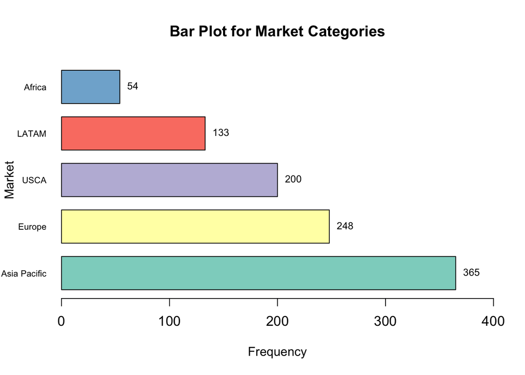

```r
#Creating Bar Plot
plot1 = barplot(table2[order(table2,decreasing = TRUE)],
                main="Bar Plot for Market Categories",
                xlab="Frequency",
                ylab="Market",
                col = brewer.pal(12, "Set3"),
                border = "black",
                xlim = c(0,400),
                 horiz = T,
                las = 1,
                 space = 0.4,
                cex.axis = 1.1,
                 cex.names = 0.7,
                )
##Adding labels for Bar chart
text(table2 [order(table2,decreasing = TRUE)],
     plot1,
     table2[order(table2,decreasing = TRUE)],
     cex=0.8,
     pos=4)
```

## Task 4 - Pie chart of product category frequencies in Africa

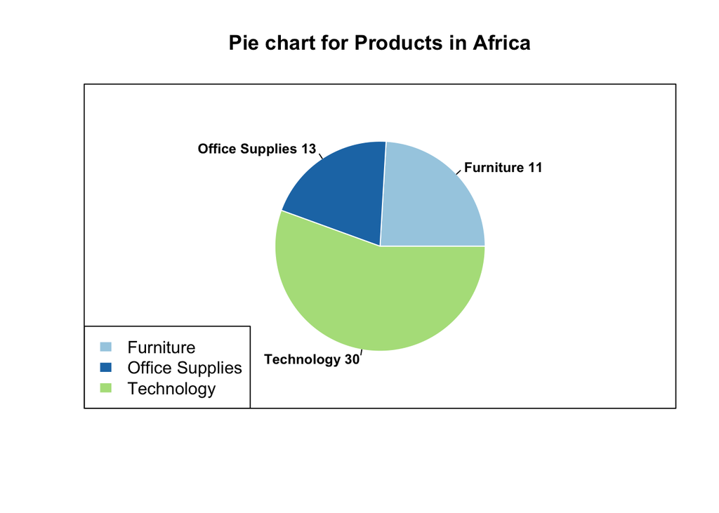

```r
#Creating a new vector for filtered Africa data from SalesData
t4Africa = dplyr::filter(SalesData, Market=="Africa")

#Calculating the frequency for Product category in Africa
freq_Africa = table(t4Africa$Product_Category)

#Adding labels for Pie chart
pieLabels = paste(unique(sort(t4Africa$Product_Category)), sort(freq_Africa))


#Creating Pie Chart
pie1 = pie(freq_Africa,main = "Pie chart for Products in Africa",
           labels = pieLabels,radius = 0.7,
           col =  brewer.pal(7, "Paired"),
           border = "white",
    lty = 1,
    cex=0.8,
    font = 2)

legend("bottomleft",
       legend = paste(unique(sort(t4Africa$Product_Category))),
       fill = brewer.pal(7, "Paired"),
       border = "white")
box(col="black")
```

## 2.4 Task 5 - Reproduce codes given by instructor

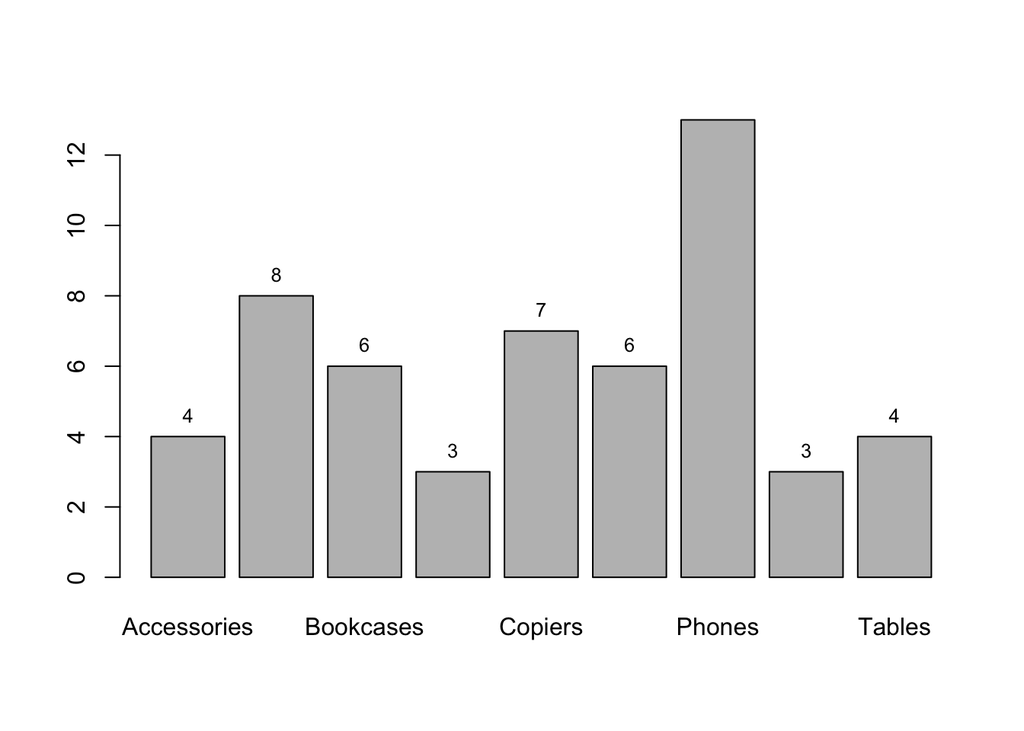

```r
# Create a table
task5_table= table(t4Africa$Product_SubCategory)

#Plot the table using a bar plot
t5bar = barplot(task5_table)

#Use text() to show the values per column
text(y=table(t4Africa$Product_SubCategory),
     t5bar,
     table(t4Africa$Product_SubCategory),
     cex= 0.8,
     pos = 3
       )
```

### 2.4.1 Observation

- The margins of graph have to be corrected as many data lables are not visible.
- We have to also increase limit on axis to show all the data.

## 2.5 Task 6 - Improve bar plot from task 5

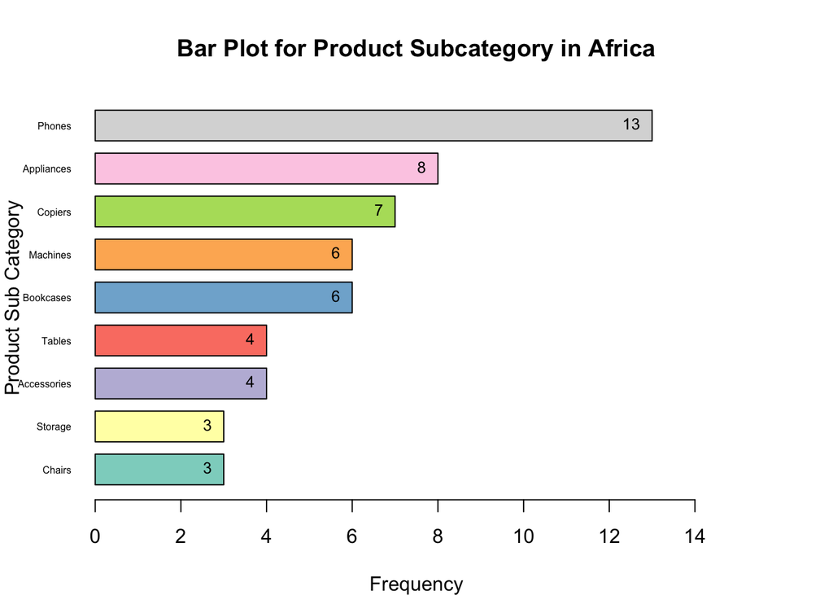

```r
par(mar = c(0.5,0.6,0.5,0.5),
    mai = c(0.8,0.8,0.8,0.8))

t5bar = barplot(task5_table[order(task5_table, decreasing = FALSE)],
                main="Bar Plot for Product Subcategory in Africa",
                 ylab = "Product Sub Category",
                 xlab = "Frequency",
                col = brewer.pal(12, "Set3"),
                border = "black",
                xlim = c(0,15),
                 las = 1.5,
                cex.lab = 1,
                cex.axis = 1,
                 cex.names = 0.5,
                 horiz = T,
                 space = 0.4)

text(task5_table [order(task5_table, decreasing = FALSE)],
     t5bar,
     task5_table [order(task5_table, decreasing = FALSE)],
     cex= 0.8,
     pos = 2)
```

### 2.5.1 Observation

- The maximum share of product subcategory is contributed by Phones (24.07%)
- On the other hand, the minimum share of products is contributed by Storage and Chairs (5.5%)
- With the above information, we can conclude that phones sales contributes around almost 5 five the number of storage or chairs sales.

## 2.6 Task 7 - Mean sales per subcategory in the African Market

```r
meanSales = tapply(t4Africa$Sales, t4Africa$Product_SubCategory, mean)

#knitr::kable(meanSales)
knitr::kable(round(meanSales,2),format = "html", col.names = c(x = "Mean"),
             table.attr="style=width: 40%", align = "lccrr") %>%
 kable_styling(bootstrap_options = c("striped", "hover", "condensed", "responsive")) %>%
  kable_classic(full_width = F, html_font = "Times New Roman")
```

|  | Mean |
| --- | --- |
| Accessories | 6478.98 |
| Appliances | 8601.98 |
| Bookcases | 10441.84 |
| Chairs | 19306.76 |
| Copiers | 26338.29 |
| Machines | 6991.88 |
| Phones | 15001.70 |
| Storage | 21289.20 |
| Tables | 14738.97 |

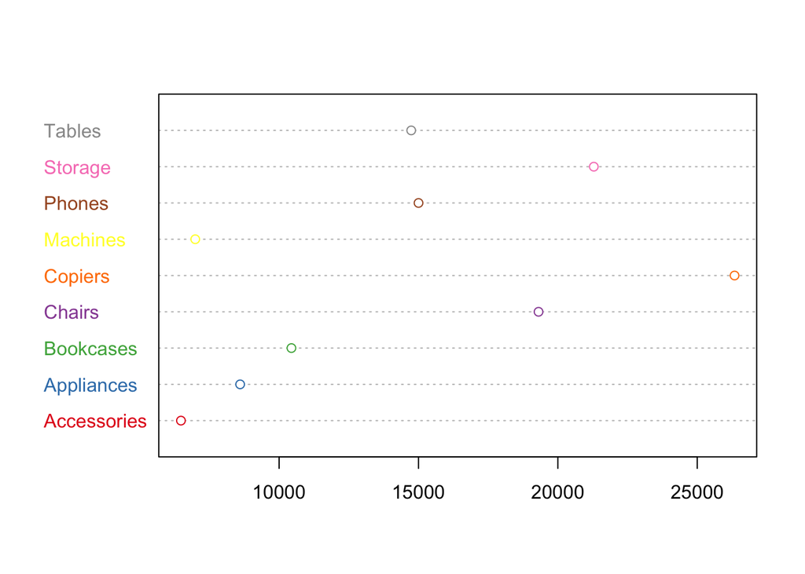

```r
#Creating dotchart
dotchart(meanSales,col = brewer.pal(11, "Set1"))
```

### 2.6.1 Observation

- The average sles of copier is maximum in the african market, which shows they are still using physical copy of paper for documentation instead of digital version
- The lowest average sale is of accessories,

## 2.7 Task 8 - Total sales per Region in the African Market

```r
par(mai=c(1.3, 1.35, 1.3, 1.3))

#Calculate the sum of sales using tapply()
TotalSales = tapply(t4Africa$Sales, t4Africa$Region, sum)


#Present the table
knitr::kable(round(TotalSales),format = "html", col.names = c(x = "Total"),
             table.attr="style=width: 40%", align = "lccrr") %>%
 kable_styling(bootstrap_options = c("striped", "hover", "condensed", "responsive")) %>%
  kable_classic(full_width = F, html_font = "Times New Roman")
```

|  | Total |
| --- | --- |
| Central Africa | 205524 |
| Eastern Africa | 96575 |
| North Africa | 178792 |
| Southern Africa | 161749 |
| Western Africa | 116827 |

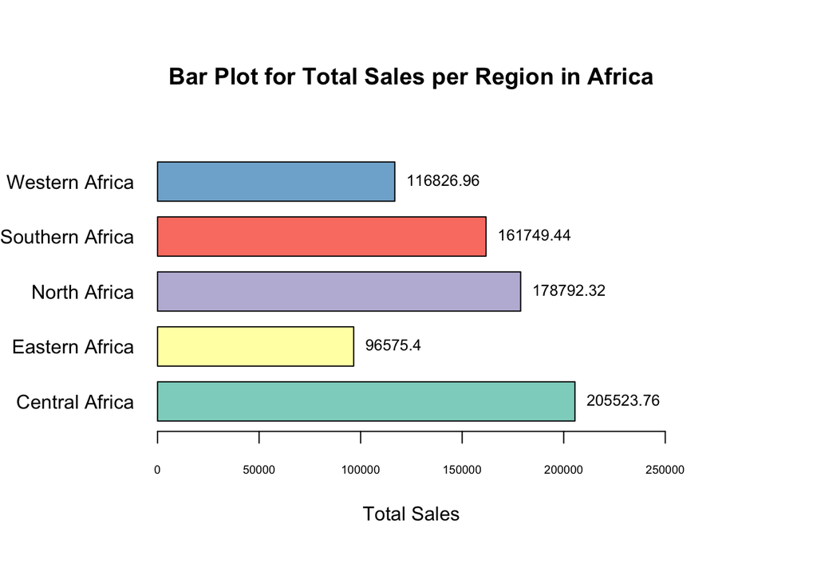

```r
t7bar = barplot(TotalSales,
                col = brewer.pal(12, "Set3"),
                main = paste("Bar Plot for Total Sales per Region in Africa"),
                xlab = paste("Total Sales"),
                las = 1,
                horiz=T,
                xlim = c(0, 250000),
                cex.lab = 1,
                cex.axis = 0.6,
                 cex.names = 1,
                 space = 0.4)
text(x=TotalSales,
     t7bar,
     TotalSales,
     cex= 0.8,
     pos = 4
       )
```

### 2.7.1 Observation

- The total sales in central africa region is highest a mong the Africa Market
- Total Sales is lowest in Eastern Africa, almost half of Central Africa

## 2.8 Task 9 - Mean shipping costs per Region in the African Market

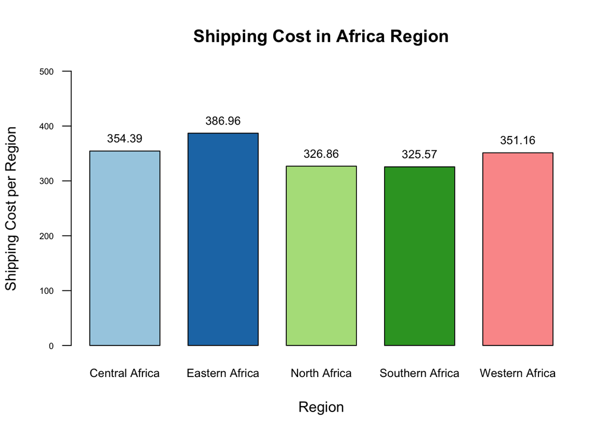

```r
#Calculate the mean for Shipping Cost using tapply()
meanShipping = tapply(t4Africa$ShippingCost, t4Africa$Region, mean, digits=2)


#Round the meanShipping value
roundShip = round(meanShipping,2)


#Barplot the meanShipping value
plotShipping = barplot(roundShip, main="Shipping Cost in Africa Region",
                ylab="Shipping Cost per Region",
                xlab="Region",
                col =  brewer.pal(7, "Paired"),
                border = "black",
               ylim=c(0,500),
                 las = 1,
                cex.lab = 1,
                cex.axis = 0.6,
                 cex.names = 0.8,
                 space = 0.4)

text(y=roundShip,
     plotShipping,
     roundShip,
     cex=0.8,
     pos = 3)
```

### 2.8.1 Observation

- The lowest shipping cost in Africa Market is in Southern Africa.
- The average cost of shipping in Africa Region is around 348

## 2.9 Task 10 - Descriptions of Data Types in R

“Datasets in R are often a combination of these 6 different data types. Below we explore in more detail each data types one by one, except the data type”complex” as we focus on the main ones and this data type is rarely used in practicev(Soetewey, 2019).

**Numeric**

The most common data type in R is numeric. A variable or a series will be stored as numeric data if the values are numbers or if the values contains decimals. For example, the following two series are stored as numeric by default:”

```r
# numeric series without decimals
num_data <- c(3, 7, 2)
num_data
```

```
## [1] 3 7 2
```

```r
## [1] 3 7 2
class(num_data)
```

```
## [1] "numeric"
```

```r
## [1] "numeric"
# numeric series with decimals
num_data_dec <- c(3.4, 7.1, 2.9)
num_data_dec
```

```
## [1] 3.4 7.1 2.9
```

```r
## [1] 3.4 7.1 2.9
class(num_data_dec)
```

```
## [1] "numeric"
```

```r
## [1] "numeric"
# also possible to check the class thanks to str()
str(num_data_dec)
```

```
##  num [1:3] 3.4 7.1 2.9
```

```r
##  num [1:3] 3.4 7.1 2.9
```

In other words, if you assign one or several numbers to an object in R, it will be stored as numeric by default (numbers with decimals), unless specified otherwise.

**Integer**

Integer data type is actually a special case of numeric data. Integers are numeric data without decimals. It can be used if you are sure that the numbers you store will never contains decimals. For example, let’s say you are interested in the number of children in a sample of 10 families. This variable is a discrete variable (see a reminder on the variable types if you do not remember what is a discrete variable) and will never have decimals. Therefore, it can be stored as integer data thanks to the as.integer() command:

```r
children <- c(1, 3, 2, 2, 4, 4, 1, 1, 1, 4)

##  [1] 1 3 2 2 4 4 1 1 1 4
children <- as.integer(children)
class(children)
```

```
## [1] "integer"
```

```r
## [1] "integer"
```

**Character**

The data type character is used when storing text, known as strings in R. The simplest ways to store data under the character format is by using “” around the piece of text:

```r
char <- "some text"
char
```

```
## [1] "some text"
```

```r
## [1] "some text"
class(char)
```

```
## [1] "character"
```

```r
## [1] "character"
```

If you want to force any kind of data to be stored as character, you can do it by using the command as.character():

```r
char2 <- as.character(children)
char2
```

```
##  [1] "1" "3" "2" "2" "4" "4" "1" "1" "1" "4"
```

```r
##  [1] "1" "3" "2" "2" "4" "4" "1" "1" "1" "4"
class(char2)
```

```
## [1] "character"
```

```r
## [1] "character"
```

Note that everything inside “” will be considered as character, no matter if it looks like character or not. For example:

```r
chars <- c("7.42")
chars
```

```
## [1] "7.42"
```

```r
## [1] "7.42"
class(chars)
```

```
## [1] "character"
```

```r
## [1] "character"
```

Furthermore, as soon as there is at least one character value inside a variable or vector, the whole variable or vector will be considered as character:

```r
char_num <- c("text", 1, 3.72, 4)
char_num
```

```
## [1] "text" "1"    "3.72" "4"
```

```r
## [1] "text" "1"    "3.72" "4"
class(char_num)
```

```
## [1] "character"
```

```r
## [1] "character"
```

Last but not least, although space does not matter in numeric data, it does matter for character data:

```r
num_space <- c(1)
num_nospace <- c(1)
# is num_space equal to num_nospace?
num_space == num_nospace
```

```
## [1] TRUE
```

```r
## [1] TRUE
char_space <- "text "
char_nospace <- "text"
# is char_space equal to char_nospace?
char_space == char_nospace
```

```
## [1] FALSE
```

```r
## [1] FALSE
```

As you can see from the results above, a space within character data (i.e., within ““) makes it a different string in R!

**Factor**

Factor variables are a special case of character variables in the sense that it also contains text. However, factor variables are used when there are a limited number of unique character strings. It often represents a categorical variable. For instance, the gender will usually take on only two values, “female” or “male” (and will be considered as a factor variable) whereas the name will generally have lots of possibilities (and thus will be considered as a character variable). To create a factor variable use the factor() function:

```r
gender <- factor(c("female", "female", "male", "female", "male"))
gender
```

```
## [1] female female male   female male
## Levels: female male
```

```r
## [1] female female male   female male
## Levels: female male
```

To know the different levels of a factor variable, use levels():

```r
levels(gender)
```

```
## [1] "female" "male"
```

```r
## [1] "female" "male"
```

By default, the levels are sorted alphabetically. You can reorder the levels with the argument levels in the factor() function:

```r
gender <- factor(gender, levels = c("male", "female"))
levels(gender)
```

```
## [1] "male"   "female"
```

```r
## [1] "male"   "female"
```

Character strings can be converted to factors with as.factor():

```r
text <- c("test1", "test2", "test1", "test1") # create a character vector
class(text) # to know the class
```

```
## [1] "character"
```

```r
## [1] "character"
text_factor <- as.factor(text) # transform to factor
class(text_factor) # recheck the class
```

```
## [1] "factor"
```

```r
## [1] "factor"
```

The character strings have been transformed to factors, as shown by its class of the type factor.

**Logical**

A logical variable is a variable with only two values; TRUE or FALSE:

```r
value1 <- 7
value2 <- 9

# is value1 greater than value2?
greater <- value1 > value2
greater
```

```
## [1] FALSE
```

```r
## [1] FALSE
class(greater)
```

```
## [1] "logical"
```

```r
## [1] "logical"
# is value1 less than or equal to value2?
less <- value1 <= value2
less
```

```
## [1] TRUE
```

```r
## [1] TRUE
class(less)
```

```
## [1] "logical"
```

```r
## [1] "logical"
```

It is also possible to transform logical data into numeric data. After the transformation from logical to numeric with the as.numeric() command, FALSE values equal to 0 and TRUE values equal to 1:

```r
greater_num <- as.numeric(greater)
sum(greater)
```

```
## [1] 0
```

```r
## [1] 0
less_num <- as.numeric(less)
sum(less)
```

```
## [1] 1
```

```r
## [1] 1
```

Conversely, numeric data can be converted to logical data, with FALSE for all values equal to 0 and TRUE for all other values.

```r
x <- 0
as.logical(x)
```

```
## [1] FALSE
```

```r
## [1] FALSE
y <- 5
as.logical(y)
```

```
## [1] TRUE
```

```r
## [1] TRUE
```

## 2.10 Task 11 - Duplicate codes presented by instructor

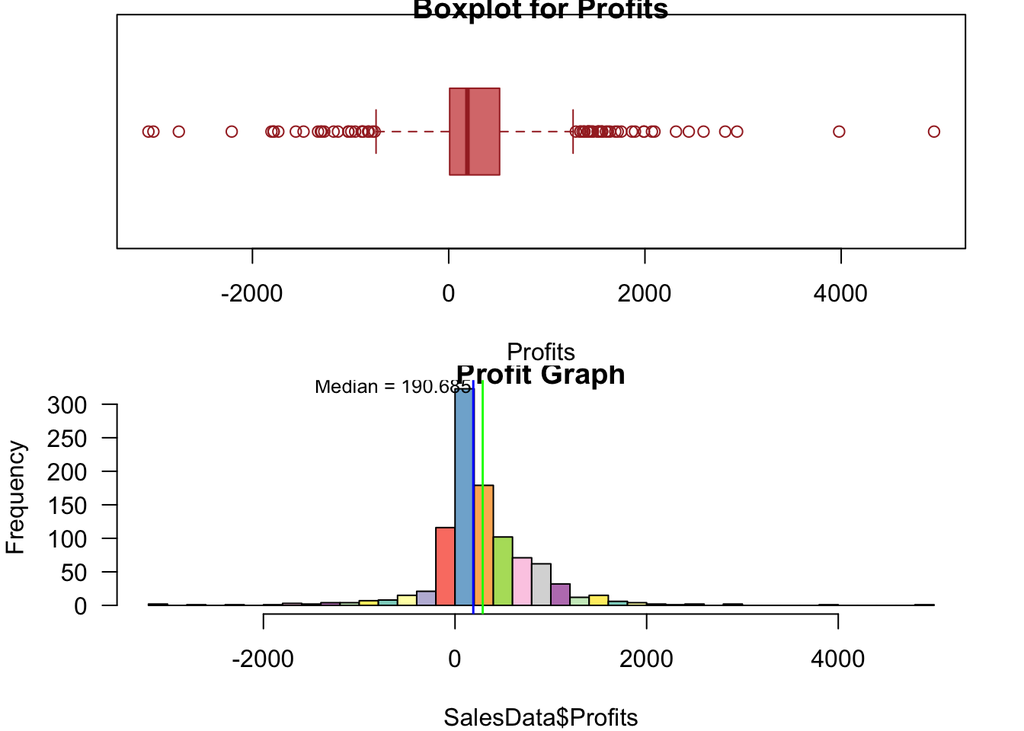

```r
# Use par() code.
# Add mfcol() to organize graphs in a matrix of 2 rows and 1 column
# Add mai=c() to control margins inside graphs
# Add mar=c() to control margins outside graphs
par(mfcol=c(2,1),
    mai=c(1,1,0.3,0.5),
    mar=c(4,4,0.5,2))

# Present a box plot of all profits
boxplot(SalesData$Profits,
        data=SalesData,
        horizontal = T,
        main="Boxplot for Profits",
xlab="Profits",
col=c("#DA7B7B","#9D8FF3", "#9D8FF7"),
border="brown",
las =1)

## Add a horizontal line for the mean
abline(h = mean(SalesData$Profits),
       col = "#7127D1",
       lwd = 1,horizontal = T)

text(y=mean(SalesData$Profits),
     x=0.55,
     paste("Mean:", round(mean(SalesData$Profits),1)),
     col = "#7127D1",
     cex = 0.8,
     pos = 3,horizontal = T)

# Present a histogram of all profits
hist(SalesData$Profits, breaks=30,main = "Profit Graph",
     col = brewer.pal(12, "Set3"),
     las = 1)

abline(v = mean(SalesData$Profits),                       # Add line for mean
       col = "green",
       lwd = 1.5)
text(x = mean(SalesData$Profits) * 1.7,                   # Add text for mean
     y = mean(SalesData$Profits) * 1.7,
     paste("Mean =", mean(SalesData$Profits)),
     col = "black",
     cex = 0.8,
     pos = 2)



abline(v = median(SalesData$Profits),                       # Add line for median
       col = "blue",
       lwd = 1.5)
text(x = median(SalesData$Profits) * 1.7,                   # Add text for mean
     y = median(SalesData$Profits) * 1.7,
     paste("Median =", median(SalesData$Profits)),
     col = "black",
     cex = 0.8,
     pos = 2)
```

## 2.11 Task 12 - Profits in the Latin American market

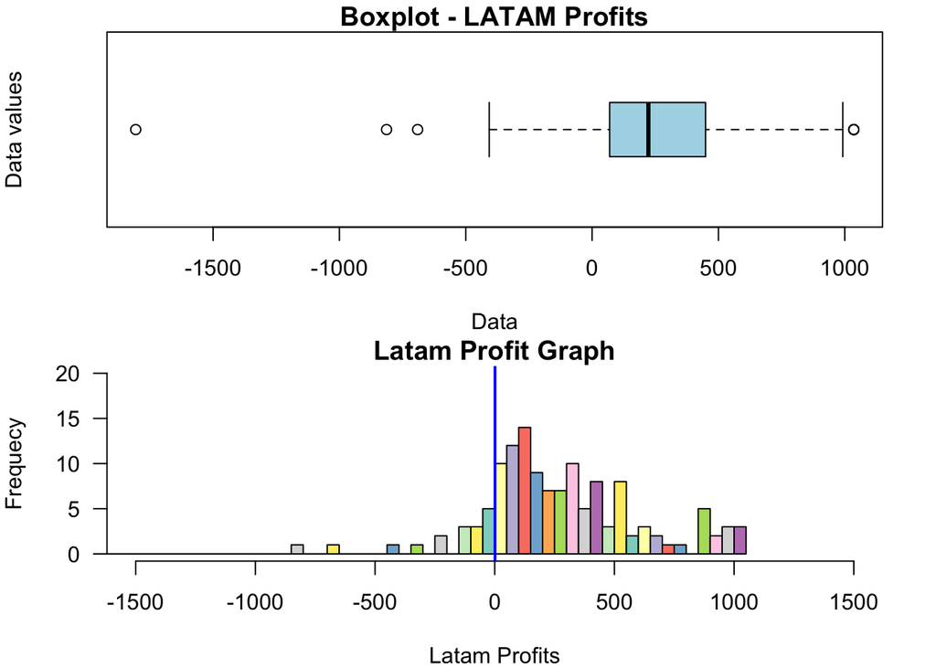

```r
# Use par() code.
# Add mfcol() to organize graphs in a matrix of 2 rows and 1 column
# Add mai=c() to control margins inside graphs
# Add mar=c() to control margins outside graphs
par(mfcol=c(2,1),
    mai=c(1, 1, 1, 1),
    mar=c(4,4,1.2,2))

#Filtering the Latam market value from SalesData
t13LATAM = dplyr::filter(SalesData, Market=="LATAM")

freq_LATAM = table(t13LATAM$Profits)

#Present a box plot of Latam profits
boxplot(t13LATAM$Profits,horizontal = T,  main="Boxplot - LATAM Profits",
        xlab="Data",
        ylab="Data values",
        las=1,
        col=c("lightblue"), boxwex=0.6,
        staplewex = 1,
        plot=TRUE)

#Present Histogram of Latam profits
hist(t13LATAM$Profits,breaks=50,main = "Latam Profit Graph",ylim = c(0,20),
     xlim = c(-1500,1500),
     ylab = "Frequecy",
     xlab = "Latam Profits",
     las =1,
     col = brewer.pal(12, "Set3"))

## Vertical line and text for the mean for Histogram
abline(v = mean(freq_LATAM),
       col = "blue",
       lwd = 2)

text(x=mean(freq_LATAM),
     y = 180,
     paste("Mean:", round(mean(freq_LATAM),1),""),
     col = "blue",
     cex = 0.8,
     pos = 4)
```

## 2.12 Task 13 - Table total sales per region in Latin America

```r
#Sum for Sales in each region in Africa
sumLatam = tapply(t13LATAM$Sales,t13LATAM$Region,sum)

#Present the Data

knitr::kable(round(sumLatam),
             caption = "Total Sales in each region in Latam",
              col.names = c("Total Sales"),
             format = "html",
             table.attr="style=width: 40%", align = "lccrr") %>%
 kable_styling(bootstrap_options = c("striped", "hover", "condensed", "responsive")) %>%
  kable_classic(full_width = F, html_font = "Times New Roman")
```

Total Sales in each region in Latam

|  | Total Sales |
| --- | --- |
| Caribbean | 196775 |
| Central America | 924226 |
| South America | 457623 |

## 2.13 Task 14 - Box plot for the profits per region in the Latin American market

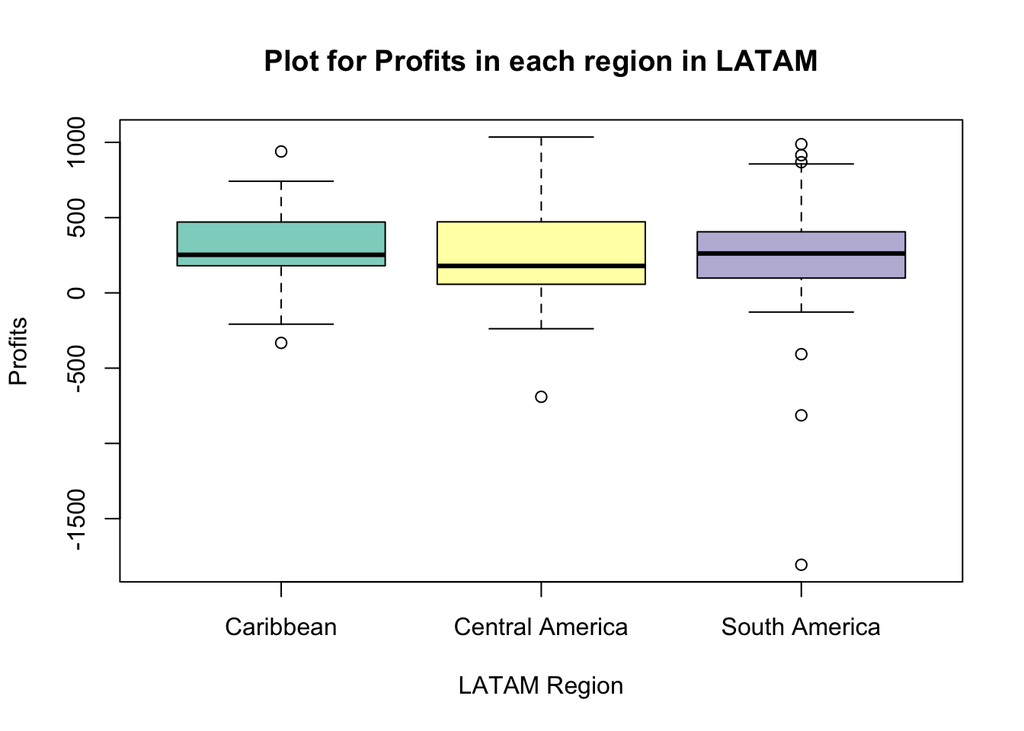

```r
boxplot(t13LATAM$Profits~t13LATAM$Region,
        main = "Plot for Profits in each region in LATAM",
        xlab=c("LATAM Region"),
        ylab = c("Profits"),
        col = brewer.pal(12, "Set3"))
```

### 2.13.1 Observation

- The most outliers are in South America Region which shows it has lot of dispersion compared to another regions.
- The median for all the region in LATAM region is around the same.
- The maximum profits was reported from Central America Region

## 2.14 Task 15 - Table with cumulative frequencies and probabilities

```r
# Create the vector for Frequency, Cumulative Frequency, Probability, Cumulative Probability

t15prod <- SalesData$Product_SubCategory %>%
  table()%>%
  as.data.frame() %>%
  rename(Column1 = Freq) %>%
  mutate(Column2 = cumsum(Column1),
         Column3 = Column1/nrow(SalesData),
         Column4 = cumsum(Column3))


#Present the table
knitr::kable(t15prod,
             digits = 2,
            caption = "Frequency distribution for Product Category",
            col.names =  c("Products","Frequency", "Cumulative Frequency", "Probability", "Cumulative Probability"),
             format = "html",
             table.attr="style=width: 40%",align = "c")%>%
kable_styling(bootstrap_options = c("striped", "hover", "condensed", "responsive")) %>%
kable_classic(full_width = TRUE, position ="center", font_size = 12)
```

Frequency distribution for Product Category

| Products | Frequency | Cumulative Frequency | Probability | Cumulative Probability |
| --- | --- | --- | --- | --- |
| Accessories | 38 | 38 | 0.04 | 0.04 |
| Appliances | 125 | 163 | 0.12 | 0.16 |
| Art | 18 | 181 | 0.02 | 0.18 |
| Binders | 38 | 219 | 0.04 | 0.22 |
| Bookcases | 130 | 349 | 0.13 | 0.35 |
| Chairs | 95 | 444 | 0.10 | 0.44 |
| Copiers | 126 | 570 | 0.13 | 0.57 |
| Envelopes | 2 | 572 | 0.00 | 0.57 |
| Fasteners | 6 | 578 | 0.01 | 0.58 |
| Furnishings | 14 | 592 | 0.01 | 0.59 |
| Labels | 6 | 598 | 0.01 | 0.60 |
| Machines | 52 | 650 | 0.05 | 0.65 |
| Paper | 32 | 682 | 0.03 | 0.68 |
| Phones | 179 | 861 | 0.18 | 0.86 |
| Storage | 45 | 906 | 0.04 | 0.91 |
| Supplies | 7 | 913 | 0.01 | 0.91 |
| Tables | 87 | 1000 | 0.09 | 1.00 |

## 2.15 Task 16 - Probability graphs

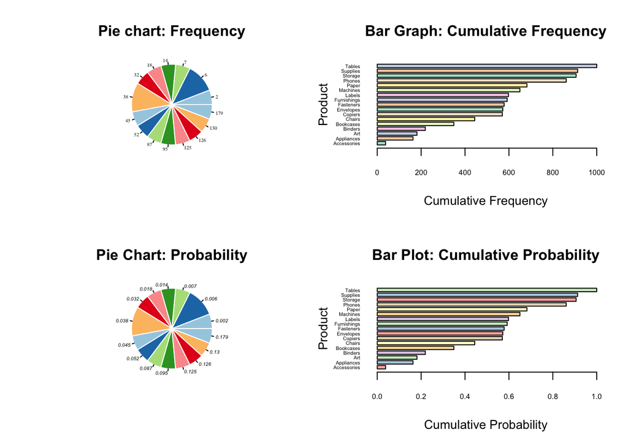

```r
#Organzing Graphs
par(mfrow=c (2,2))



#Calculating the frequency for Product Sub_category
freq_t15 = table(t15prod$Column1)

#Adding labels for Pie chart
pieLabels = paste(unique(sort(t15prod$Column1)), sort(freq_t15))


#Creating Pie Chart
pie1 = pie(freq_t15,main = "Pie chart: Frequency",
         radius =1,
           col =  brewer.pal(7, "Paired"),
           border = "white",
    lty = 1,
    cex=0.4,
    font = 5)



#Bar chart for Cumulative frequency
barFreq = barplot(t15prod$Column2~t15prod$., main = "Bar Graph: Cumulative Frequency",
                ylab="Product",
                xlab="Cumulative Frequency",
                col =  brewer.pal(7, "Pastel2"),
                 las = 1,horiz=T,
                cex.lab = 1,
                cex.axis = 0.6,
                 cex.names = 0.4,
                 space = 0.4)




#Pie chart for Probability
#Calculating the frequency for Product Sub_category
freq_t15 = table(t15prod$Column3)

#Adding labels for Pie chart
pieLabels = paste(unique(sort(t15prod$Column3)), sort(freq_t15))


#Creating Pie Chart
pie1 = pie(freq_t15,main = "Pie Chart: Probability",
         radius =1,round = 2,
           col =  brewer.pal(7, "Paired"),
           border = "white",
    lty = 1,
    cex=0.4,
    font = 3)




#Bar chart for Cumulative probability
barFreq = barplot(t15prod$Column4~t15prod$., main = "Bar Plot: Cumulative Probability",
                ylab="Product",
                xlab="Cumulative Probability",
                col =  brewer.pal(7, "Pastel1"),
             horiz = T,
                 las = 1,
                cex.lab = 1,
                cex.axis = 0.6,
                 cex.names = 0.4,
                 space = 0.4)
```

## 2.16 Task 17 - Free graph

[figure not shown]

```r
t17piechart  <- table(SalesData$Market)

pieLabel4 = paste(unique(sort(SalesData$Market)), sort(t17piechart))

pie1 = pie(t17piechart, labels = pieLabel4,
           radius = 0.8,
           col =  brewer.pal(7, "Pastel2"),
    border = "white",
    lty = 1,
    cex=0.8,
    font = 3)

legend("topleft",
       legend = paste(unique(sort(SalesData$Market))),
       fill = brewer.pal(7, "Pastel2"),
       border = "white")
box(col="black")


box(col="black")
```

# 3 Conclusions

**After working on this project, Below are skills that I have learned and improved upon**

1. Problem Solving Capability: I have learned to tackle the problem more logically
2. Attention to Detail: Paying attention to details is necessary, because one mistake in syntax or logic, could hamper your results
3. Patience: We need a lot a patience, because when I was coding, I have written some code. I was extremely confident in it. I double and triple checked it, and it wasn’t working properly. Then, I have to go back again and view the code from start.
4. Debugging Skills: I have improved my debugging skills by trying to find root cause, whenever code was getting struck and wasn’t giving expected results.

# 4 Biblography

1. Braun, W. J., & Murdoch, D. J. (2021). A first course in statistical programming with R. Cambridge University Press.
2. Chambers, J. M. (2008). Software for data analysis: programming with R (Vol. 2). New York: Springer.
3. Cotton, R. (2013). Learning R (First edition.). O’Reilly.
4. Peng, R. D. (2016). R programming for data science (pp. 86-181). Victoria, BC, Canada: Leanpub.
5. Sackmann, E. (1996). Supported Membranes: Scientific and Practical Applications. Science, 271(5245), 43–48. doi:10.1126/science.271.5245.43
6. Soetewey, A. (2019, December 30). Data types in R. Stats and R. https://statsandr.com/blog/data-types-in-r/

# 5 Appendix

An R Markdown file has been attached to this report. The name of the file is Narasaiah_ALY6000Project2